# Resampling

Resampling based procedures are ways to perform population based statistical inferences, while living within our data. Data Scientists tend to really like resampling based inferences, since they are very data centric procedures, they scale well to large studies and they often make very few assumptions.

## The bootstrap

The bootstrap is a tremendously useful tool for constructing confidence intervals and calculating standard errors for difficult statistics For example, how would one derive a confidence interval for the median? The bootstrap procedure follows from the so called bootstrap principle

Sample of 50 die rolls

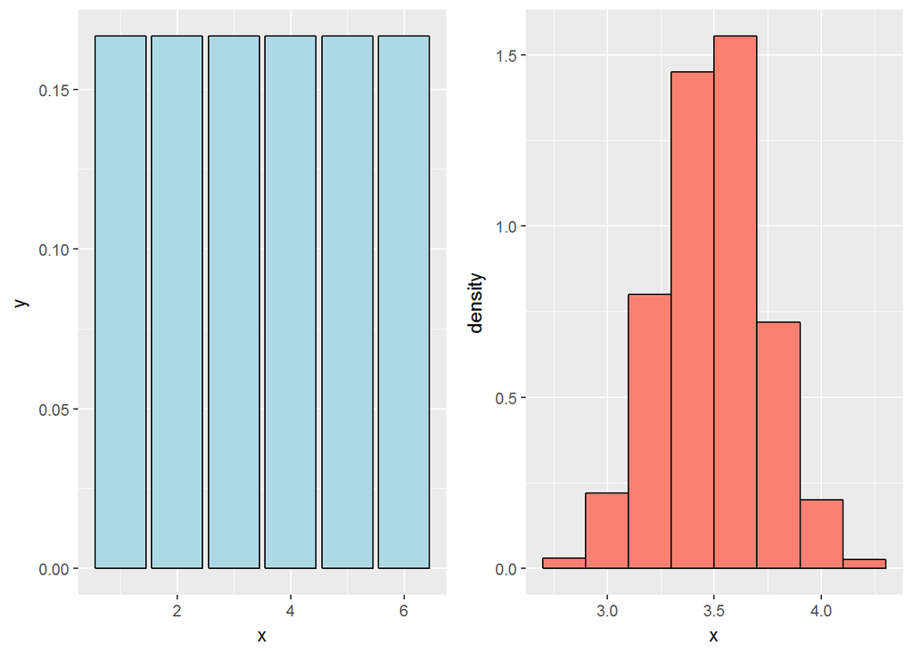

```r
library(ggplot2)
library(gridExtra)
nosim <- 1000

cfunc <- function(x, n) mean(x)
g1 = ggplot(data.frame(y = rep(1/6, 6), x = 1 : 6), aes(y = y, x = x))
g1 = g1 + geom_bar(stat = "identity", fill = "lightblue", colour = "black")

dat <- data.frame(x = apply(matrix(sample(1 : 6, nosim * 50, replace = TRUE),
                     nosim), 1, mean))
g2 <- ggplot(dat, aes(x = x)) + geom_histogram(binwidth=.2, colour = "black", fill = "salmon", aes(y = ..density..))

grid.arrange(g1, g2, ncol = 2)
```

What if we only had one sample?

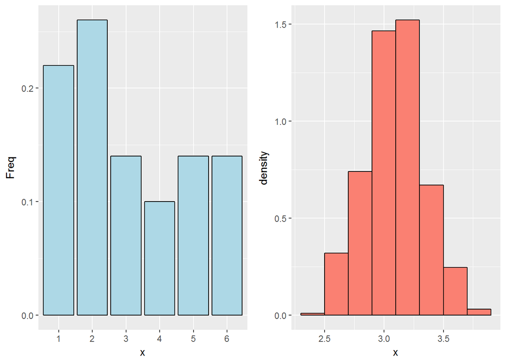

```r
n = 50
B = 1000
## our data
x = sample(1 : 6, n, replace = TRUE)
## bootstrap resamples
resamples = matrix(sample(x,
                           n * B,
                           replace = TRUE),
                    B, n)
resampledMeans = apply(resamples, 1, mean)
g1 <- ggplot(as.data.frame(prop.table(table(x))), aes(x = x, y = Freq)) + geom_bar(colour = "black", fill = "lightblue", stat = "identity")
g2 <- ggplot(data.frame(x = resampledMeans), aes(x = x)) + geom_histogram(binwidth=.2, colour = "black", fill = "salmon", aes(y = ..density..))
grid.arrange(g1, g2, ncol = 2)
```

Consider a data set

```r
library(UsingR)
```

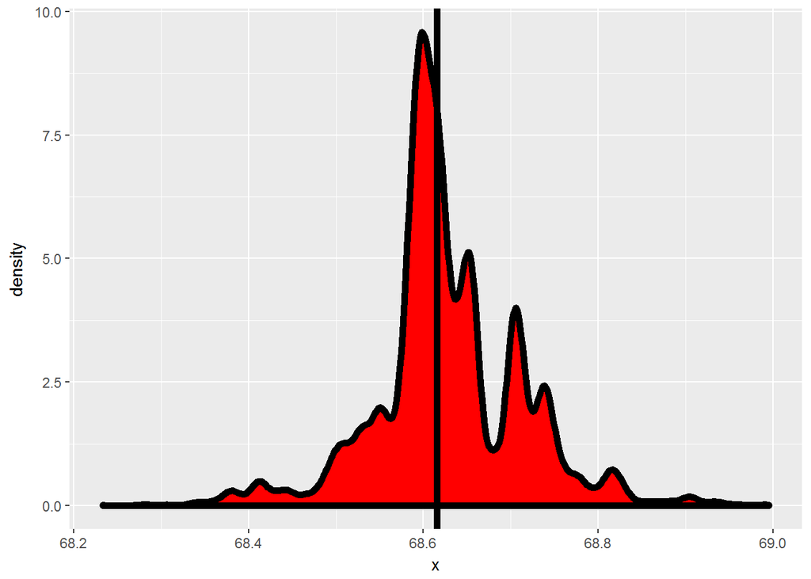

```r
data(father.son)
x <- father.son$sheight
n <- length(x)
B <- 10000
resamples <- matrix(sample(x,
                           n * B,
                           replace = TRUE),
                    B, n)
resampledMedians <- apply(resamples, 1, median)
# A plot of the histrogram of the resamples
g = ggplot(data.frame(x = resampledMedians), aes(x = x))
g = g + geom_density(size = 2, fill = "red")
#g = g + geom_histogram(alpha = .20, binwidth=.3, colour = "black", fill = "blue", aes(y = ..density..))
g = g + geom_vline(xintercept = median(x), size = 2)
g
```

## The bootstrap principle

Suppose that I have a statistic that estimates some population parameter, but I don’t know its sampling distribution The bootstrap principle suggests using the distribution defined by the data to approximate its sampling distribution

The bootstrap in practice

In practice, the bootstrap principle is always carried out using simulation

We will cover only a few aspects of bootstrap resampling

The general procedure follows by first simulating complete data sets from the observed data with replacement

This is approximately drawing from the sampling distribution of that statistic, at least as far as the data is able to approximate the true population distribution Calculate the statistic for each simulated data set

Use the simulated statistics to either define a confidence interval or take the standard deviation to calculate a standard error

## Nonparametric bootstrap algorithm example

Bootstrap procedure for calculating confidence interval for the median from a data set of $n$ observations

1. Sample $n$ observations with replacement from the observed data resulting in one simulated complete data set
2. Take the median of the simulated data set
3. Repeat these two steps $B$ times, resulting in $B$ simulated medians
4. These medians are approximately drawn from the sampling distribution of the median of $n$ observations; therefore we can

Draw a histogram of them Calculate their standard deviation to estimate the standard error of the median Take the $2.5^{th}$ and $97.5^{th}$ percentiles as a confidence interval for the median

Example code

```r
B <- 10000
resamples <- matrix(sample(x,
                           n * B,
                           replace = TRUE),
                    B, n)
medians <- apply(resamples, 1, median)
sd(medians)
```

```
## [1] 0.08314735
```

```r
quantile(medians, c(.025, .975))
```

```
##     2.5%    97.5%
## 68.42972 68.81413
```

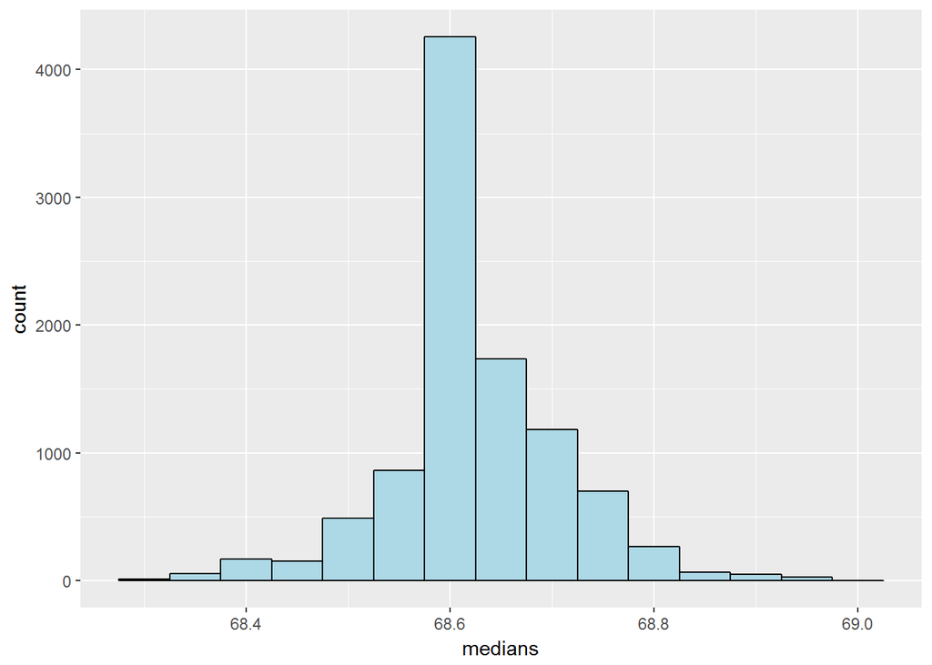

```r
#Histogram of bootstrap resamples
g = ggplot(data.frame(medians = medians), aes(x = medians))
g = g + geom_histogram(color = "black", fill = "lightblue", binwidth = 0.05)
g
```

## Notes on the bootstrap

The bootstrap is non-parametric Better percentile bootstrap confidence intervals correct for bias There are lots of variations on bootstrap procedures; the book “An Introduction to the Bootstrap”" by Efron and Tibshirani is a great place to start for both bootstrap and jackknife information

Group comparisons

Consider comparing two independent groups. Example, comparing sprays B and C

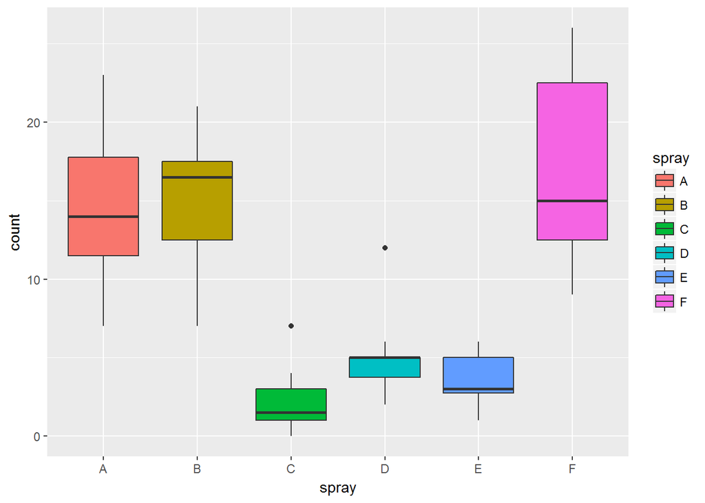

```r
data(InsectSprays)
g = ggplot(InsectSprays, aes(spray, count, fill = spray))
g = g + geom_boxplot()
g
```

## Permutation tests

Consider the null hypothesis that the distribution of the observations from each group is the same Then, the group labels are irrelevant Consider a data frome with count and spray Permute the spray (group) labels Recalculate the statistic Mean difference in counts Geometric means T statistic Calculate the percentage of simulations where the simulated statistic was more extreme (toward the alternative) than the observed

Variations on permutation testing

Also, so-called randomization tests are exactly permutation tests, with a different motivation. For matched data, one can randomize the signs For ranks, this results in the signed rank test Permutation strategies work for regression as well Permuting a regressor of interest Permutation tests work very well in multivariate settings

Permutation test B v C

```r
subdata <- InsectSprays[InsectSprays$spray %in% c("B", "C"),]
y <- subdata$count
group <- as.character(subdata$spray)
testStat <- function(w, g) mean(w[g == "B"]) - mean(w[g == "C"])
observedStat <- testStat(y, group)
permutations <- sapply(1 : 10000, function(i) testStat(y, sample(group)))
observedStat
```

```
## [1] 13.25
```

```r
mean(permutations > observedStat)
```

```
## [1] 0
```

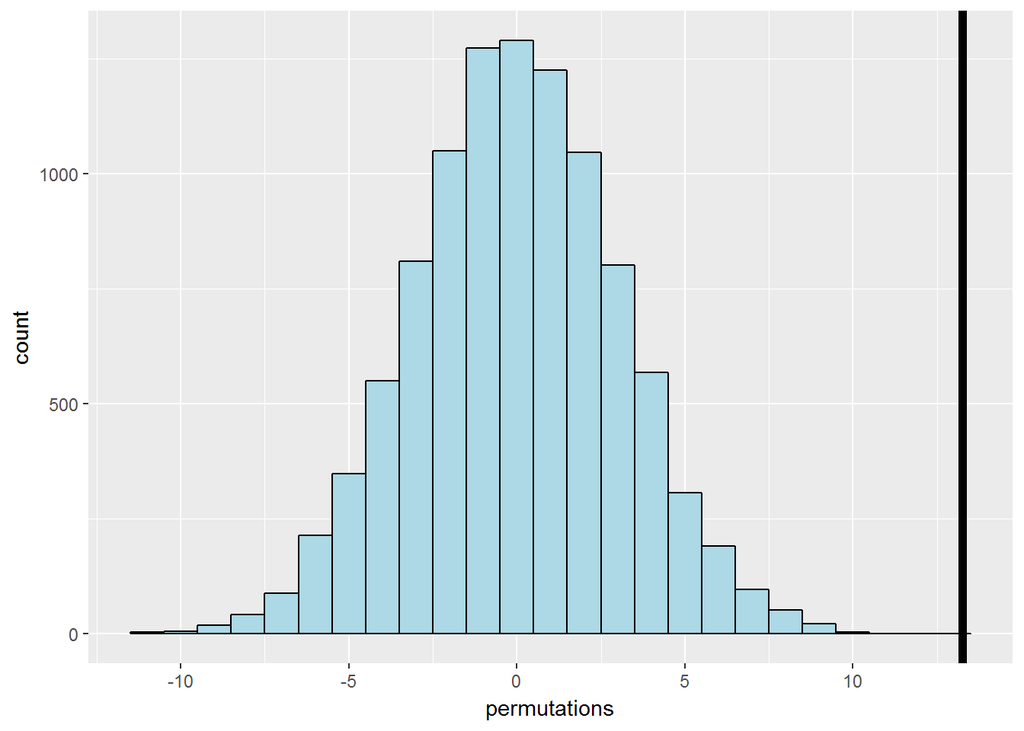

```r
#Histogram of permutations B v C

g = ggplot(data.frame(permutations = permutations),
           aes(permutations))
g = g + geom_histogram(fill = "lightblue", color = "black", binwidth = 1)
g = g + geom_vline(xintercept = observedStat, size = 2)
g
```